# Tarjetas Black

Vamos a utilizar un dataset de movimientos de tarjetas de crédito que provienen de [tarjetas Black](https://www.eldiario.es/politica/tarjetas-banquillo-empresarios-sindicalistas-politicos_1_1907519.html).

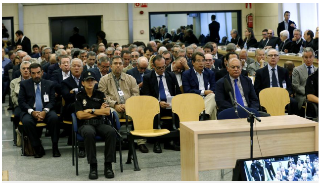

El origen es el siguiente fuente:

https://www.cuartopoder.es/multimedia/2014/10/11/gastos-de-los-exdirectivos-de-caja-madrid-uno-a-uno-con-las-tarjetas-negras-tabla/3403

## Modelo conceptual

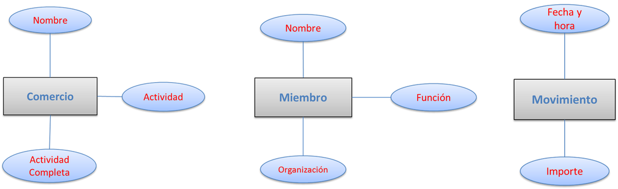

## Modelo de relación

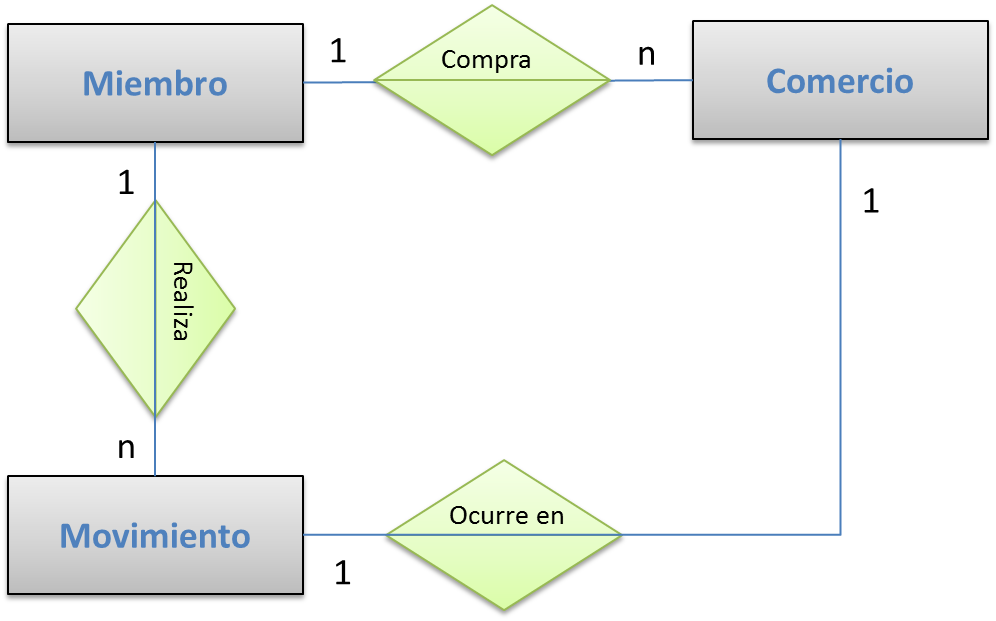

## Contenido de la información

Contiene la siguiente información:

- Nombre: Nombre de la persona que posee la tarjeta y realiza el movimiento
- Fecha: Fecha del movimiento
- Hora: Hora del movimiento
- Minuto: Minuto del movimiento
- Importe: Importe del movimiento
- Comercio donde se realiza el movimiento
- Actividad Completa: Detalle de la que se dedica el comercio
- Actividad: Contiene una clasificación de la actividad del comercio. Una Actividad puede agrupar a varios comercios
- Función: Función que desempeña la persona dentro de su organización (Sólo para los partidos políticos)
- Organización: Organización a la que pertenece la persona que realiza el gasto

Podrían existir movimientos con campos vacíos.

## Formato del fichero

El fichero con los datos está comprimido, en formato CSV, y utiliza el carácter ~ cómo separador de columnas.

## Preguntas

Vamos a intentar resolver las siguientes preguntas:

- Los 10 movimientos mas caros por actividad
- Los 10 movimientos mas caros
- Los movimientos de una persona concreta (ordenados por importe)
- Las 10 personas que mas han gastado
- Importes de una persona agrupados por actividad
- ¿Quién se gasta más, los concejales o los directivos?
- ¿Qué organización se gasta más?
- ¿Qué comercio es más popular entre los miembros?

# Preprocesado de datos

Se realizará un preprocesado de datos cuyo objetico es limpiar y normalizar los datos para que se puedan utilizar más fácilmente por el resto de prácticas

El formato de salida será un fichero Microsoft Excel que contendrá los siguientes datasets:

- Movimientos: Movimientos donde se han eliminado los atributos personales y se han sustituido por un ID
- Miembros: Dataset con todas las personas que han realzado movimientos

```python
import numpy as np
import pandas as pd
```

```python
df = pd.read_csv("./data/black.txt.gz", compression='gzip', sep='~',  index_col=False, low_memory=False)
```

```python
df.head()
```

|  | nombre | fecha | hora | minuto | importe | comercio | actividad_completa | actividad | funcion | organizacion |
| --- | --- | --- | --- | --- | --- | --- | --- | --- | --- | --- |
| 0 | Alberto Recarte García Andrade | 2003-01-03 | 12 | 30 | 38.70 | RCG OFICINA | CONFECCION TEXTIL EN GENERAL | ROPA | concejal | Partido Popular |
| 1 | Alberto Recarte García Andrade | 2003-01-03 | 12 | 32 | 14.60 | MANZANIL AREA | HOTELES,MOTELES,BALNEARIOS,CAMPINGS REST | HOTEL | concejal | Partido Popular |
| 2 | Alberto Recarte García Andrade | 2003-01-04 | 19 | 7 | 95.62 | REST REAL C GOLF SOTOGRAN | RESTAURANTES RESTO | RESTAURANTE | concejal | Partido Popular |
| 3 | Alberto Recarte García Andrade | 2003-01-07 | 15 | 31 | 49.13 | ESTACONES DE SERVICIO ML | GASOLINERAS | COCHE | concejal | Partido Popular |
| 4 | Alberto Recarte García Andrade | 2003-01-07 | 16 | 5 | 13.93 | NISA (H 24) VINHOLAN S.A. | GASOLINERAS | COCHE | concejal | Partido Popular |

Nos quedamos sólo con los registros únicos

```python
df_miembros = df.filter(["nombre", "funcion", "organizacion"]) \
                .drop_duplicates()
df_miembros.head()
```

|  | nombre | funcion | organizacion |
| --- | --- | --- | --- |
| 0 | Alberto Recarte García Andrade | concejal | Partido Popular |
| 1305 | Alejandro Couceiro Ojeda | concejal | CEIM |
| 1851 | Ángel Eugenio Gómez del Pulgar Perales | concejal | PSOE |
| 2832 | Angel Rizaldos González | concejal | Izquierda Unida |
| 2952 | Antonio Cámara Eguinoa | concejal | Partido Popular |

Se crea un dataset de miembros, asignado a cada persona un ID único

```python
df_miembros.sort_values(by = "nombre").assign(
        id_miembro = df_miembros.nombre.rank().astype(int)
).head()
```

|  | nombre | funcion | organizacion | id_miembro |
| --- | --- | --- | --- | --- |
| 0 | Alberto Recarte García Andrade | concejal | Partido Popular | 1 |
| 1305 | Alejandro Couceiro Ojeda | concejal | CEIM | 2 |
| 2832 | Angel Rizaldos González | concejal | Izquierda Unida | 3 |
| 2952 | Antonio Cámara Eguinoa | concejal | Partido Popular | 4 |
| 6292 | Antonio Rey de Viñas Sánchez-Majestad | concejal | CC OO | 5 |

```python
df_miembros = (df_miembros
    .assign(id_miembro = df_miembros.nombre.rank(method='min').astype(int))
    .filter(['id_miembro', 'nombre', 'funcion', 'organizacion'])
)
```

```python
df_miembros.head()
```

|  | id_miembro | nombre | funcion | organizacion |
| --- | --- | --- | --- | --- |
| 0 | 1 | Alberto Recarte García Andrade | concejal | Partido Popular |
| 1305 | 2 | Alejandro Couceiro Ojeda | concejal | CEIM |
| 1851 | 83 | Ángel Eugenio Gómez del Pulgar Perales | concejal | PSOE |
| 2832 | 3 | Angel Rizaldos González | concejal | Izquierda Unida |
| 2952 | 4 | Antonio Cámara Eguinoa | concejal | Partido Popular |

Se inserta en el dataset principal el ID creado anteriormente

```python
df_result = pd.merge(df, df_miembros, on = ['nombre', 'funcion', 'organizacion'], how = 'inner')
df_result.head()
```

|  | nombre | fecha | hora | minuto | importe | comercio | actividad_completa | actividad | funcion | organizacion | id_miembro |
| --- | --- | --- | --- | --- | --- | --- | --- | --- | --- | --- | --- |
| 0 | Alberto Recarte García Andrade | 2003-01-03 | 12 | 30 | 38.70 | RCG OFICINA | CONFECCION TEXTIL EN GENERAL | ROPA | concejal | Partido Popular | 1 |
| 1 | Alberto Recarte García Andrade | 2003-01-03 | 12 | 32 | 14.60 | MANZANIL AREA | HOTELES,MOTELES,BALNEARIOS,CAMPINGS REST | HOTEL | concejal | Partido Popular | 1 |
| 2 | Alberto Recarte García Andrade | 2003-01-04 | 19 | 7 | 95.62 | REST REAL C GOLF SOTOGRAN | RESTAURANTES RESTO | RESTAURANTE | concejal | Partido Popular | 1 |
| 3 | Alberto Recarte García Andrade | 2003-01-07 | 15 | 31 | 49.13 | ESTACONES DE SERVICIO ML | GASOLINERAS | COCHE | concejal | Partido Popular | 1 |
| 4 | Alberto Recarte García Andrade | 2003-01-07 | 16 | 5 | 13.93 | NISA (H 24) VINHOLAN S.A. | GASOLINERAS | COCHE | concejal | Partido Popular | 1 |

Seleccionamos las columnas que nos interesan

```python
df_movimientos = df_result.filter(
    ['id_miembro','fecha', 'hora', 'minuto', 'importe', 'comercio', 'actividad_completa', 'actividad']
)
```

Eliminamos la información horaria de la fecha

```python
df_movimientos = df_movimientos.assign(
    fecha = pd.to_datetime(df['fecha']).dt.date
)
df_movimientos.info()
```

```
<class 'pandas.core.frame.DataFrame'>
Int64Index: 76238 entries, 0 to 76237
Data columns (total 8 columns):
 #   Column              Non-Null Count  Dtype
---  ------              --------------  -----
 0   id_miembro          76238 non-null  int64
 1   fecha               76238 non-null  object
 2   hora                76238 non-null  int64
 3   minuto              76238 non-null  int64
 4   importe             76238 non-null  float64
 5   comercio            68500 non-null  object
 6   actividad_completa  76221 non-null  object
 7   actividad           76220 non-null  object
dtypes: float64(1), int64(3), object(4)
memory usage: 5.2+ MB
```

```python
df_movimientos.head()
```

|  | id_miembro | fecha | hora | minuto | importe | comercio | actividad_completa | actividad |
| --- | --- | --- | --- | --- | --- | --- | --- | --- |
| 0 | 1 | 2003-01-03 | 12 | 30 | 38.70 | RCG OFICINA | CONFECCION TEXTIL EN GENERAL | ROPA |
| 1 | 1 | 2003-01-03 | 12 | 32 | 14.60 | MANZANIL AREA | HOTELES,MOTELES,BALNEARIOS,CAMPINGS REST | HOTEL |
| 2 | 1 | 2003-01-04 | 19 | 7 | 95.62 | REST REAL C GOLF SOTOGRAN | RESTAURANTES RESTO | RESTAURANTE |
| 3 | 1 | 2003-01-07 | 15 | 31 | 49.13 | ESTACONES DE SERVICIO ML | GASOLINERAS | COCHE |
| 4 | 1 | 2003-01-07 | 16 | 5 | 13.93 | NISA (H 24) VINHOLAN S.A. | GASOLINERAS | COCHE |

Y por último selecionamos al azar un 10% de los datos para que la práctica sea más ágil ...

```python
df_movimientos_lite = df_movimientos.sample(frac=0.10, random_state = 1313)
df_movimientos_lite.info()
```

```
<class 'pandas.core.frame.DataFrame'>
Int64Index: 7624 entries, 51501 to 35498
Data columns (total 8 columns):
 #   Column              Non-Null Count  Dtype
---  ------              --------------  -----
 0   id_miembro          7624 non-null   int64
 1   fecha               7624 non-null   object
 2   hora                7624 non-null   int64
 3   minuto              7624 non-null   int64
 4   importe             7624 non-null   float64
 5   comercio            6882 non-null   object
 6   actividad_completa  7621 non-null   object
 7   actividad           7621 non-null   object
dtypes: float64(1), int64(3), object(4)
memory usage: 536.1+ KB
```

```python
df_movimientos_lite.head()
```

|  | id_miembro | fecha | hora | minuto | importe | comercio | actividad_completa | actividad |
| --- | --- | --- | --- | --- | --- | --- | --- | --- |
| 51501 | 77 | 2006-04-17 | 11 | 40 | 44.56 | FCIA TORRES MU¬OZ | FARMACIAS | SALUD |
| 13619 | 15 | 2010-09-11 | 14 | 26 | 67.56 | E.S.VEGONES DER | C.A.M.P.S.A. | COCHE |
| 22298 | 29 | 2003-01-24 | 14 | 15 | 191.00 | EL CORTE INGLES | EL CORTE INGLES | COMPRA BIENES |
| 65305 | 74 | 2007-05-10 | 15 | 2 | 599.20 | VIAJES ECI | EL CORTE INGLES | COMPRA BIENES |
| 52699 | 77 | 2010-12-18 | 14 | 35 | 3.65 | PK VELAZQUEZ JORGE JUAN | GARAJES Y APARCAMIENTOS | COCHE |

Grabamos el resultado en un fichero Excel donde cada dataset estará en un hoja diferente

```python
writer = pd.ExcelWriter("./data/black.xlsx")
df_movimientos_lite.to_excel(writer,'Movimientos', index=False)
df_miembros.to_excel(writer, 'Miembros', index=False)
writer.save()
```